# ANCOVA in Palavras Lidas (1 Min) (Palavras Lidas (1 Min))

Geiser C. Challco geiser@alumni.usp.br

- Descriptive Statistics of Initial Data
- ANCOVA and Pairwise for one factor: **grupo**
  - Without remove non-normal data
  - Computing ANCOVA and PairWise After removing non-normal data (OK)
    - Plots for ancova
    - Checking linearity assumption
    - Checking normality and homogeneity
- ANCOVA and Pairwise for two factors **grupo:Sexo**
  - Without remove non-normal data
  - Computing ANCOVA and PairWise After removing non-normal data (OK)
    - Plots for ancova
    - Checking linearity assumption
    - Checking normality and homogeneity
- ANCOVA and Pairwise for two factors **grupo:Zona**
  - Without remove non-normal data
  - Computing ANCOVA and PairWise After removing non-normal data (OK)
    - Plots for ancova
    - Checking linearity assumption
    - Checking normality and homogeneity
- ANCOVA and Pairwise for two factors **grupo:Cor.Raca**
  - Without remove non-normal data
  - Computing ANCOVA and PairWise After removing non-normal data (OK)
    - Plots for ancova
    - Checking linearity assumption
    - Checking normality and homogeneity
- ANCOVA and Pairwise for two factors **grupo:TFL.lidas.per.min.quintile**
  - Without remove non-normal data
  - Computing ANCOVA and PairWise After removing non-normal data (OK)
    - Plots for ancova
    - Checking linearity assumption
    - Checking normality and homogeneity
- Summary of Results
  - Descriptive Statistics
  - ANCOVA Table Comparison
  - PairWise Table Comparison
  - EMMS Table Comparison

**NOTE**:

- Teste ANCOVA para determinar se houve diferenças significativas no Palavras Lidas (1 Min) (medido usando pre- e pos-testes).
- ANCOVA test to determine whether there were significant differences in Palavras Lidas (1 Min) (measured using pre- and post-tests).

# Descriptive Statistics of Initial Data

```r
df <- get.descriptives(dat, c(dv.pre, dv.pos), c("grupo"),
                       include.global = T, symmetry.test = T, normality.test = F)
df <- plyr::rbind.fill(
  df, do.call(plyr::rbind.fill, lapply(lfatores2, FUN = function(f) {
    if (nrow(dat) > 0 && sum(!is.na(unique(dat[[f]]))) > 1)
      get.descriptives(dat, c(dv.pre,dv.pos), c("grupo", f),
                       symmetry.test = T, normality.test = F)
    }))
)
(df <- df[,c(fatores1[fatores1 %in% colnames(df)],"variable",
             colnames(df)[!colnames(df) %in% c(fatores1,"variable")])])
```

```
##           grupo Sexo   Zona Cor.Raca TFL.lidas.per.min.quintile              variable   n    mean median min max
## 1      Controle <NA>   <NA>     <NA>                       <NA> TFL.lidas.per.min.pre  91  91.923   94.0  27 154
## 2  Experimental <NA>   <NA>     <NA>                       <NA> TFL.lidas.per.min.pre  53  93.528   95.0  54 135
## 3          <NA> <NA>   <NA>     <NA>                       <NA> TFL.lidas.per.min.pre 144  92.514   95.0  27 154
## 4      Controle <NA>   <NA>     <NA>                       <NA> TFL.lidas.per.min.pos  91 113.593  114.0  43 187
## 5  Experimental <NA>   <NA>     <NA>                       <NA> TFL.lidas.per.min.pos  53 114.774  112.0  67 195
## 6          <NA> <NA>   <NA>     <NA>                       <NA> TFL.lidas.per.min.pos 144 114.028  112.0  43 195
## 7      Controle    F   <NA>     <NA>                       <NA> TFL.lidas.per.min.pre  36  93.917   96.5  40 154
## 8      Controle    M   <NA>     <NA>                       <NA> TFL.lidas.per.min.pre  55  90.618   92.0  27 141
## 9  Experimental    F   <NA>     <NA>                       <NA> TFL.lidas.per.min.pre  22  98.455   96.5  60 135
## 10 Experimental    M   <NA>     <NA>                       <NA> TFL.lidas.per.min.pre  31  90.032   90.0  54 135
## 11     Controle    F   <NA>     <NA>                       <NA> TFL.lidas.per.min.pos  36 121.194  118.5  87 187
## 12     Controle    M   <NA>     <NA>                       <NA> TFL.lidas.per.min.pos  55 108.618  108.0  43 176
## 13 Experimental    F   <NA>     <NA>                       <NA> TFL.lidas.per.min.pos  22 125.318  117.5  82 195
## 14 Experimental    M   <NA>     <NA>                       <NA> TFL.lidas.per.min.pos  31 107.290  101.0  67 184
```

[output cut: 98 more lines]

| grupo | Sexo | Zona | Cor.Raca | TFL.lidas.per.min.quintile | variable | n | mean | median | min | max | sd | se | ci | iqr | symmetry | skewness | kurtosis |
| --- | --- | --- | --- | --- | --- | --- | --- | --- | --- | --- | --- | --- | --- | --- | --- | --- | --- |
| Controle |  |  |  |  | TFL.lidas.per.min.pre | 91 | 91.923 | 94.0 | 27 | 154 | 24.115 | 2.528 | 5.022 | 30.50 | YES | -0.184 | -0.128 |
| Experimental |  |  |  |  | TFL.lidas.per.min.pre | 53 | 93.528 | 95.0 | 54 | 135 | 19.277 | 2.648 | 5.313 | 27.00 | YES | -0.069 | -0.471 |
|  |  |  |  |  | TFL.lidas.per.min.pre | 144 | 92.514 | 95.0 | 27 | 154 | 22.399 | 1.867 | 3.690 | 29.00 | YES | -0.183 | -0.033 |
| Controle |  |  |  |  | TFL.lidas.per.min.pos | 91 | 113.593 | 114.0 | 43 | 187 | 28.508 | 2.988 | 5.937 | 44.00 | YES | 0.253 | -0.327 |
| Experimental |  |  |  |  | TFL.lidas.per.min.pos | 53 | 114.774 | 112.0 | 67 | 195 | 27.425 | 3.767 | 7.559 | 40.00 | NO | 0.701 | 0.273 |
|  |  |  |  |  | TFL.lidas.per.min.pos | 144 | 114.028 | 112.0 | 43 | 195 | 28.024 | 2.335 | 4.616 | 42.00 | YES | 0.408 | -0.068 |
| Controle | F |  |  |  | TFL.lidas.per.min.pre | 36 | 93.917 | 96.5 | 40 | 154 | 24.110 | 4.018 | 8.158 | 23.75 | YES | -0.129 | 0.165 |
| Controle | M |  |  |  | TFL.lidas.per.min.pre | 55 | 90.618 | 92.0 | 27 | 141 | 24.250 | 3.270 | 6.556 | 33.50 | YES | -0.214 | -0.440 |
| Experimental | F |  |  |  | TFL.lidas.per.min.pre | 22 | 98.455 | 96.5 | 60 | 135 | 17.470 | 3.725 | 7.746 | 22.25 | YES | -0.190 | -0.260 |
| Experimental | M |  |  |  | TFL.lidas.per.min.pre | 31 | 90.032 | 90.0 | 54 | 135 | 20.001 | 3.592 | 7.336 | 19.50 | YES | 0.105 | -0.607 |
| Controle | F |  |  |  | TFL.lidas.per.min.pos | 36 | 121.194 | 118.5 | 87 | 187 | 26.148 | 4.358 | 8.847 | 37.00 | NO | 0.615 | -0.443 |
| Controle | M |  |  |  | TFL.lidas.per.min.pos | 55 | 108.618 | 108.0 | 43 | 176 | 29.114 | 3.926 | 7.871 | 42.00 | YES | 0.196 | -0.580 |
| Experimental | F |  |  |  | TFL.lidas.per.min.pos | 22 | 125.318 | 117.5 | 82 | 195 | 26.032 | 5.550 | 11.542 | 38.75 | NO | 0.587 | 0.116 |
| Experimental | M |  |  |  | TFL.lidas.per.min.pos | 31 | 107.290 | 101.0 | 67 | 184 | 26.267 | 4.718 | 9.635 | 26.00 | NO | 0.962 | 0.822 |
| Controle |  | Rural |  |  | TFL.lidas.per.min.pre | 58 | 91.914 | 94.5 | 27 | 154 | 26.233 | 3.445 | 6.898 | 38.25 | YES | -0.189 | -0.347 |
| Controle |  | Urbana |  |  | TFL.lidas.per.min.pre | 7 | 93.000 | 99.0 | 48 | 124 | 24.055 | 9.092 | 22.248 | 19.00 | NO | -0.586 | -0.815 |
| Controle |  |  |  |  | TFL.lidas.per.min.pre | 26 | 91.654 | 92.0 | 54 | 139 | 19.626 | 3.849 | 7.927 | 22.25 | YES | 0.088 | -0.247 |
| Experimental |  | Rural |  |  | TFL.lidas.per.min.pre | 35 | 90.714 | 90.0 | 54 | 135 | 18.909 | 3.196 | 6.496 | 19.00 | YES | 0.062 | -0.526 |
| Experimental |  | Urbana |  |  | TFL.lidas.per.min.pre | 6 | 102.667 | 95.5 | 90 | 135 | 17.455 | 7.126 | 18.318 | 15.25 | NO | 0.921 | -0.930 |
| Experimental |  |  |  |  | TFL.lidas.per.min.pre | 12 | 97.167 | 98.5 | 54 | 117 | 20.683 | 5.971 | 13.141 | 32.00 | NO | -0.611 | -0.922 |
| Controle |  | Rural |  |  | TFL.lidas.per.min.pos | 58 | 106.276 | 105.5 | 43 | 187 | 25.144 | 3.302 | 6.611 | 31.50 | YES | 0.330 | 0.649 |
| Controle |  | Urbana |  |  | TFL.lidas.per.min.pos | 7 | 142.857 | 150.0 | 88 | 176 | 28.399 | 10.734 | 26.264 | 23.00 | NO | -0.735 | -0.690 |
| Controle |  |  |  |  | TFL.lidas.per.min.pos | 26 | 122.038 | 128.0 | 68 | 176 | 29.198 | 5.726 | 11.793 | 42.25 | YES | 0.007 | -1.036 |
| Experimental |  | Rural |  |  | TFL.lidas.per.min.pos | 35 | 109.371 | 105.0 | 70 | 184 | 23.204 | 3.922 | 7.971 | 22.50 | NO | 1.008 | 1.248 |
| Experimental |  | Urbana |  |  | TFL.lidas.per.min.pos | 6 | 134.333 | 123.0 | 99 | 195 | 34.541 | 14.101 | 36.248 | 31.00 | NO | 0.685 | -1.190 |
| Experimental |  |  |  |  | TFL.lidas.per.min.pos | 12 | 120.750 | 133.0 | 67 | 166 | 31.758 | 9.168 | 20.178 | 48.75 | YES | -0.359 | -1.448 |
| Controle |  |  | Branca |  | TFL.lidas.per.min.pre | 12 | 105.500 | 103.5 | 90 | 141 | 15.895 | 4.588 | 10.099 | 25.00 | NO | 0.771 | -0.536 |
| Controle |  |  | Indígena |  | TFL.lidas.per.min.pre | 3 | 117.000 | 101.0 | 96 | 154 | 32.140 | 18.556 | 79.841 | 29.00 | few data | 0.000 | 0.000 |
| Controle |  |  | Parda |  | TFL.lidas.per.min.pre | 42 | 92.381 | 95.0 | 27 | 135 | 23.486 | 3.624 | 7.319 | 33.00 | NO | -0.511 | -0.178 |
| Controle |  |  | Preta |  | TFL.lidas.per.min.pre | 1 | 99.000 | 99.0 | 99 | 99 |  |  |  | 0.00 | few data | 0.000 | 0.000 |
| Controle |  |  |  |  | TFL.lidas.per.min.pre | 33 | 83.909 | 85.0 | 40 | 139 | 24.108 | 4.197 | 8.548 | 39.00 | YES | 0.119 | -0.757 |
| Experimental |  |  | Amarela |  | TFL.lidas.per.min.pre | 1 | 76.000 | 76.0 | 76 | 76 |  |  |  | 0.00 | few data | 0.000 | 0.000 |
| Experimental |  |  | Branca |  | TFL.lidas.per.min.pre | 5 | 104.000 | 96.0 | 95 | 117 | 11.874 | 5.310 | 14.744 | 22.00 | few data | 0.000 | 0.000 |
| Experimental |  |  | Indígena |  | TFL.lidas.per.min.pre | 8 | 95.125 | 98.5 | 54 | 115 | 19.342 | 6.839 | 16.171 | 14.25 | NO | -1.028 | -0.229 |
| Experimental |  |  | Parda |  | TFL.lidas.per.min.pre | 16 | 88.688 | 86.0 | 54 | 135 | 20.261 | 5.065 | 10.796 | 17.00 | NO | 0.549 | -0.209 |
| Experimental |  |  |  |  | TFL.lidas.per.min.pre | 23 | 94.826 | 95.0 | 59 | 135 | 19.878 | 4.145 | 8.596 | 24.00 | YES | -0.085 | -0.758 |
| Controle |  |  | Branca |  | TFL.lidas.per.min.pos | 12 | 115.417 | 116.5 | 87 | 150 | 18.143 | 5.237 | 11.528 | 15.75 | YES | 0.092 | -0.875 |
| Controle |  |  | Indígena |  | TFL.lidas.per.min.pos | 3 | 118.667 | 117.0 | 92 | 147 | 27.538 | 15.899 | 68.408 | 27.50 | few data | 0.000 | 0.000 |
| Controle |  |  | Parda |  | TFL.lidas.per.min.pos | 42 | 101.095 | 96.0 | 43 | 187 | 25.697 | 3.965 | 8.008 | 29.00 | NO | 0.745 | 1.536 |
| Controle |  |  | Preta |  | TFL.lidas.per.min.pos | 1 | 118.000 | 118.0 | 118 | 118 |  |  |  | 0.00 | few data | 0.000 | 0.000 |
| Controle |  |  |  |  | TFL.lidas.per.min.pos | 33 | 128.242 | 135.0 | 68 | 176 | 29.130 | 5.071 | 10.329 | 42.00 | YES | -0.309 | -0.824 |
| Experimental |  |  | Amarela |  | TFL.lidas.per.min.pos | 1 | 82.000 | 82.0 | 82 | 82 |  |  |  | 0.00 | few data | 0.000 | 0.000 |
| Experimental |  |  | Branca |  | TFL.lidas.per.min.pos | 5 | 126.600 | 121.0 | 110 | 151 | 18.609 | 8.322 | 23.106 | 31.00 | YES | 0.254 | -2.082 |
| Experimental |  |  | Indígena |  | TFL.lidas.per.min.pos | 8 | 106.875 | 112.0 | 67 | 139 | 21.290 | 7.527 | 17.799 | 16.75 | YES | -0.427 | -0.751 |
| Experimental |  |  | Parda |  | TFL.lidas.per.min.pos | 16 | 100.750 | 97.0 | 70 | 145 | 19.039 | 4.760 | 10.145 | 10.75 | NO | 0.737 | 0.167 |
| Experimental |  |  |  |  | TFL.lidas.per.min.pos | 23 | 126.130 | 130.0 | 80 | 195 | 30.697 | 6.401 | 13.274 | 43.50 | YES | 0.450 | -0.569 |
| Controle |  |  |  | 1st quintile | TFL.lidas.per.min.pre | 15 | 53.267 | 54.0 | 27 | 67 | 9.669 | 2.497 | 5.355 | 5.50 | NO | -1.196 | 1.265 |
| Controle |  |  |  | 2nd quintile | TFL.lidas.per.min.pre | 19 | 78.263 | 81.0 | 68 | 86 | 6.814 | 1.563 | 3.284 | 11.00 | YES | -0.392 | -1.481 |
| Controle |  |  |  | 3rd quintile | TFL.lidas.per.min.pre | 15 | 91.600 | 92.0 | 88 | 95 | 2.530 | 0.653 | 1.401 | 3.50 | YES | -0.072 | -1.435 |
| Controle |  |  |  | 4th quintile | TFL.lidas.per.min.pre | 23 | 102.609 | 102.0 | 96 | 110 | 4.261 | 0.889 | 1.843 | 6.50 | YES | 0.475 | -1.090 |
| Controle |  |  |  | 5th quintile | TFL.lidas.per.min.pre | 19 | 123.421 | 118.0 | 112 | 154 | 11.217 | 2.573 | 5.406 | 10.00 | NO | 1.297 | 0.630 |
| Experimental |  |  |  | 1st quintile | TFL.lidas.per.min.pre | 5 | 58.600 | 59.0 | 54 | 66 | 4.980 | 2.227 | 6.183 | 6.00 | YES | 0.346 | -1.732 |
| Experimental |  |  |  | 2nd quintile | TFL.lidas.per.min.pre | 12 | 77.417 | 79.5 | 68 | 86 | 6.360 | 1.836 | 4.041 | 8.00 | YES | -0.441 | -1.376 |
| Experimental |  |  |  | 3rd quintile | TFL.lidas.per.min.pre | 13 | 91.923 | 90.0 | 88 | 95 | 2.900 | 0.804 | 1.752 | 5.00 | YES | -0.005 | -1.903 |
| Experimental |  |  |  | 4th quintile | TFL.lidas.per.min.pre | 11 | 100.818 | 99.0 | 96 | 110 | 5.382 | 1.623 | 3.616 | 8.00 | NO | 0.661 | -1.378 |
| Experimental |  |  |  | 5th quintile | TFL.lidas.per.min.pre | 12 | 119.250 | 117.0 | 113 | 135 | 7.485 | 2.161 | 4.756 | 0.50 | NO | 1.445 | 0.342 |
| Controle |  |  |  | 1st quintile | TFL.lidas.per.min.pos | 15 | 93.467 | 88.0 | 43 | 149 | 29.715 | 7.672 | 16.456 | 33.50 | YES | 0.326 | -0.949 |
| Controle |  |  |  | 2nd quintile | TFL.lidas.per.min.pos | 19 | 104.632 | 95.0 | 67 | 139 | 24.683 | 5.663 | 11.897 | 44.50 | YES | 0.214 | -1.577 |
| Controle |  |  |  | 3rd quintile | TFL.lidas.per.min.pos | 15 | 107.067 | 96.0 | 81 | 150 | 22.827 | 5.894 | 12.641 | 36.50 | NO | 0.552 | -1.311 |
| Controle |  |  |  | 4th quintile | TFL.lidas.per.min.pos | 23 | 124.174 | 118.0 | 91 | 171 | 23.704 | 4.943 | 10.250 | 32.00 | YES | 0.448 | -0.945 |
| Controle |  |  |  | 5th quintile | TFL.lidas.per.min.pos | 19 | 130.789 | 128.0 | 90 | 187 | 27.614 | 6.335 | 13.309 | 25.00 | NO | 0.520 | -0.698 |
| Experimental |  |  |  | 1st quintile | TFL.lidas.per.min.pos | 5 | 96.000 | 93.0 | 67 | 150 | 32.435 | 14.505 | 40.273 | 20.00 | NO | 0.726 | -1.300 |
| Experimental |  |  |  | 2nd quintile | TFL.lidas.per.min.pos | 12 | 93.500 | 92.5 | 70 | 145 | 18.594 | 5.368 | 11.814 | 14.75 | NO | 1.535 | 2.169 |
| Experimental |  |  |  | 3rd quintile | TFL.lidas.per.min.pos | 13 | 111.231 | 110.0 | 93 | 139 | 14.066 | 3.901 | 8.500 | 16.00 | NO | 0.566 | -0.740 |
| Experimental |  |  |  | 4th quintile | TFL.lidas.per.min.pos | 11 | 125.000 | 115.0 | 95 | 195 | 28.415 | 8.567 | 19.089 | 25.50 | NO | 1.235 | 0.597 |
| Experimental |  |  |  | 5th quintile | TFL.lidas.per.min.pos | 12 | 138.333 | 137.0 | 99 | 184 | 22.329 | 6.446 | 14.187 | 18.00 | YES | 0.316 | -0.433 |

# ANCOVA and Pairwise for one factor: **grupo**

## Without remove non-normal data

```r
pdat = remove_group_data(dat[!is.na(dat[["grupo"]]),], "TFL.lidas.per.min.pos", "grupo")

pdat.long <- rbind(pdat[,c("id","grupo")], pdat[,c("id","grupo")])
pdat.long[["time"]] <- c(rep("pre", nrow(pdat)), rep("pos", nrow(pdat)))
pdat.long[["time"]] <- factor(pdat.long[["time"]], c("pre","pos"))
pdat.long[["TFL.lidas.per.min"]] <- c(pdat[["TFL.lidas.per.min.pre"]], pdat[["TFL.lidas.per.min.pos"]])

aov = anova_test(pdat, TFL.lidas.per.min.pos ~ TFL.lidas.per.min.pre + grupo)
laov[["grupo"]] <- get_anova_table(aov)
```

```r
pwc <- emmeans_test(pdat, TFL.lidas.per.min.pos ~ grupo, covariate = TFL.lidas.per.min.pre,
                    p.adjust.method = "bonferroni")
```

```r
pwc.long <- emmeans_test(dplyr::group_by_at(pdat.long, "grupo"),
                          TFL.lidas.per.min ~ time,
                          p.adjust.method = "bonferroni")
lpwc[["grupo"]] <- plyr::rbind.fill(pwc, pwc.long)
```

```r
ds <- get.descriptives(pdat, "TFL.lidas.per.min.pos", "grupo", covar = "TFL.lidas.per.min.pre")
ds <- merge(ds[ds$variable != "TFL.lidas.per.min.pre",],
            ds[ds$variable == "TFL.lidas.per.min.pre", !colnames(ds) %in% c("variable")],
            by = "grupo", all.x = T, suffixes = c("", ".TFL.lidas.per.min.pre"))
ds <- merge(get_emmeans(pwc), ds, by = "grupo", suffixes = c(".emms", ""))
ds <- ds[,c("grupo","n","mean.TFL.lidas.per.min.pre","se.TFL.lidas.per.min.pre","mean","se","emmean","se.emms")]

colnames(ds) <- c("grupo", "N", paste0(c("M","SE")," (pre)"),
                  paste0(c("M","SE"), " (unadj)"), paste0(c("M", "SE"), " (adj)"))

lemms[["grupo"]] <- ds
```

## Computing ANCOVA and PairWise After removing non-normal data (OK)

```r
wdat = pdat

res = residuals(lm(TFL.lidas.per.min.pos ~ TFL.lidas.per.min.pre + grupo, data = wdat))
non.normal = getNonNormal(res, wdat$id, plimit = 0.05)

wdat = wdat[!wdat$id %in% non.normal,]

wdat.long <- rbind(wdat[,c("id","grupo")], wdat[,c("id","grupo")])
wdat.long[["time"]] <- c(rep("pre", nrow(wdat)), rep("pos", nrow(wdat)))
wdat.long[["time"]] <- factor(wdat.long[["time"]], c("pre","pos"))
wdat.long[["TFL.lidas.per.min"]] <- c(wdat[["TFL.lidas.per.min.pre"]], wdat[["TFL.lidas.per.min.pos"]])

ldat[["grupo"]] = wdat

(non.normal)
```

```
##  [1] "P463"  "P956"  "P3498" "P3609" "P3721" "P3516" "P808"  "P445"  "P3521" "P3504" "P1010" "P3729" "P446"
## [14] "P1109" "P465"  "P3492" "P942"  "P3581" "P1091" "P820"  "P1094" "P3627" "P621"  "P3566" "P184"  "P133"
## [27] "P628"  "P3501" "P816"  "P1017" "P950"  "P947"  "P1097" "P3495" "P3615" "P1716" "P3505" "P3512" "P3524"
## [40] "P3565" "P3502" "P128"  "P1089" "P812"  "P521"  "P448"  "P3558" "P3606" "P3518" "P3624" "P1004" "P994"
## [53] "P1000" "P616"  "P618"  "P829"  "P241"  "P451"  "P515"  "P615"  "P460"  "P813"  "P936"  "P614"  "P457"
## [66] "P513"  "P958"  "P516"  "P1084" "P997"  "P626"  "P3509" "P3734" "P613"  "P3598" "P1107" "P512"  "P464"
## [79] "P625"  "P612"  "P3560" "P3519" "P620"  "P523"  "P948"  "P2210" "P3508" "P943"  "P3577" "P176"  "P3569"
## [92] "P1742"
```

```r
aov = anova_test(wdat, TFL.lidas.per.min.pos ~ TFL.lidas.per.min.pre + grupo)
laov[["grupo"]] <- merge(get_anova_table(aov), laov[["grupo"]], by="Effect", suffixes = c("","'"))

(df = get_anova_table(aov))
```

```
## ANOVA Table (type II tests)
##
##                  Effect DFn DFd      F       p p<.05   ges
## 1 TFL.lidas.per.min.pre   1  49 39.759 7.9e-08     * 0.448
## 2                 grupo   1  49  0.929 3.4e-01       0.019
```

| Effect | DFn | DFd | F | p | p<.05 | ges |
| --- | --- | --- | --- | --- | --- | --- |
| TFL.lidas.per.min.pre | 1 | 49 | 39.759 | 0.00 | * | 0.448 |
| grupo | 1 | 49 | 0.929 | 0.34 |  | 0.019 |

| term | .y. | group1 | group2 | df | statistic | p | p.adj | p.adj.signif |
| --- | --- | --- | --- | --- | --- | --- | --- | --- |
| TFL.lidas.per.min.pre*grupo | TFL.lidas.per.min.pos | Controle | Experimental | 49 | 0.964 | 0.34 | 0.34 | ns |

```r
pwc.long <- emmeans_test(dplyr::group_by_at(wdat.long, "grupo"),
                         TFL.lidas.per.min ~ time,
                         p.adjust.method = "bonferroni")
lpwc[["grupo"]] <- merge(plyr::rbind.fill(pwc, pwc.long), lpwc[["grupo"]], by=c("grupo","term",".y.","group1","group2"), suffixes = c("","'"))
```

| grupo | term | .y. | group1 | group2 | df | statistic | p | p.adj | p.adj.signif |
| --- | --- | --- | --- | --- | --- | --- | --- | --- | --- |
| Controle | time | TFL.lidas.per.min | pre | pos | 100 | -9.206 | 0 | 0 | **** |
| Experimental | time | TFL.lidas.per.min | pre | pos | 100 | -5.917 | 0 | 0 | **** |

```r
ds <- get.descriptives(wdat, "TFL.lidas.per.min.pos", "grupo", covar = "TFL.lidas.per.min.pre")
ds <- merge(ds[ds$variable != "TFL.lidas.per.min.pre",],
            ds[ds$variable == "TFL.lidas.per.min.pre", !colnames(ds) %in% c("variable")],
            by = "grupo", all.x = T, suffixes = c("", ".TFL.lidas.per.min.pre"))
ds <- merge(get_emmeans(pwc), ds, by = "grupo", suffixes = c(".emms", ""))
ds <- ds[,c("grupo","n","mean.TFL.lidas.per.min.pre","se.TFL.lidas.per.min.pre","mean","se","emmean","se.emms")]

colnames(ds) <- c("grupo", "N", paste0(c("M","SE")," (pre)"),
                  paste0(c("M","SE"), " (unadj)"), paste0(c("M", "SE"), " (adj)"))

lemms[["grupo"]] <- merge(ds, lemms[["grupo"]], by=c("grupo"), suffixes = c("","'"))
```

| grupo | N | M (pre) | SE (pre) | M (unadj) | SE (unadj) | M (adj) | SE (adj) |
| --- | --- | --- | --- | --- | --- | --- | --- |
| Controle | 33 | 87.364 | 4.315 | 139.000 | 3.971 | 141.414 | 3.045 |
| Experimental | 19 | 96.947 | 4.019 | 140.684 | 5.427 | 136.492 | 4.036 |

### Plots for ancova

```r
plots <- oneWayAncovaPlots(
  wdat, "TFL.lidas.per.min.pos", "grupo", aov, list("grupo"=pwc), addParam = c("mean_se"),
  font.label.size=10, step.increase=0.05, p.label="p.adj",
  subtitle = which(aov$Effect == "grupo"))
```

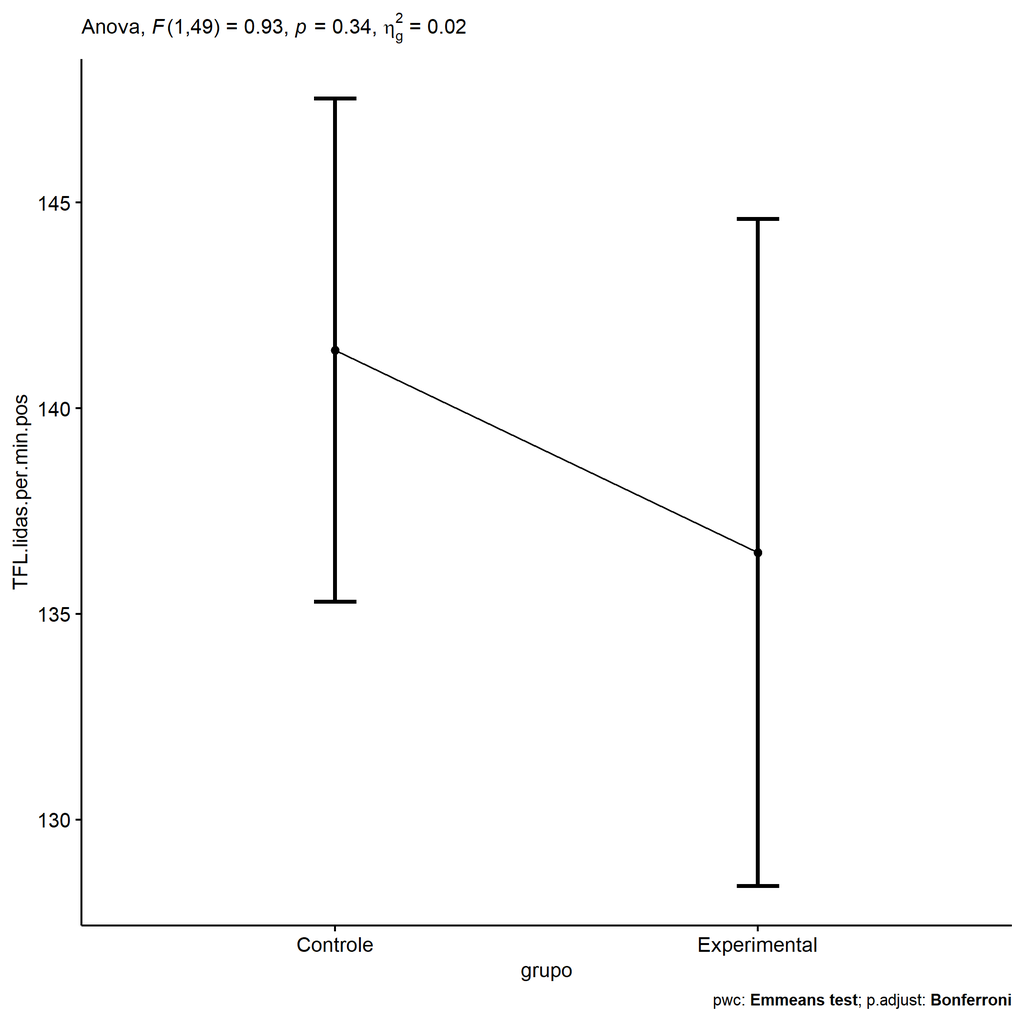

```r
if (!is.null(nrow(plots[["grupo"]]$data)))
  plots[["grupo"]] + ggplot2::scale_color_manual(values = color[["grupo"]])
```

```r
plots <- oneWayAncovaBoxPlots(
  wdat, "TFL.lidas.per.min.pos", "grupo", aov, pwc, covar = "TFL.lidas.per.min.pre",
  theme = "classic", color = color[["grupo"]],
  subtitle = which(aov$Effect == "grupo"))
```

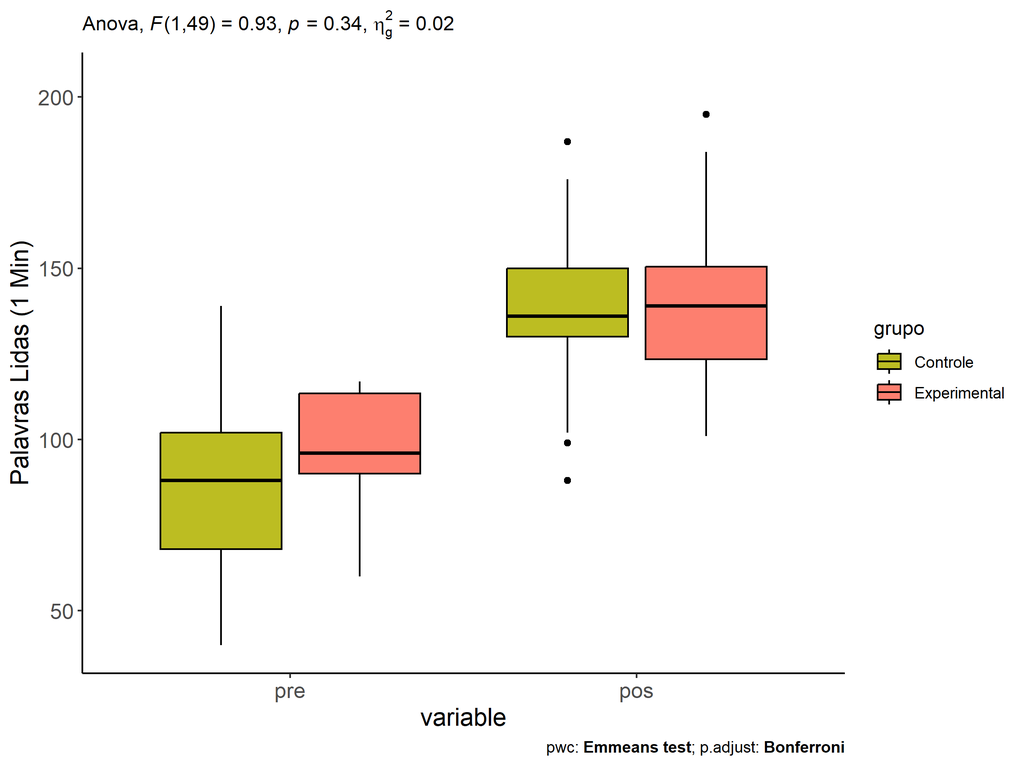

```r
if (length(unique(wdat[["grupo"]])) > 1)
  plots[["grupo"]] + ggplot2::ylab("Palavras Lidas (1 Min)") + ggplot2::scale_x_discrete(labels=c('pre', 'pos'))
```

```r
if (length(unique(wdat.long[["grupo"]])) > 1)
  plots <- oneWayAncovaBoxPlots(
    wdat.long, "TFL.lidas.per.min", "grupo", aov, pwc.long, pre.post = "time",
    theme = "classic", color = color$prepost)
```

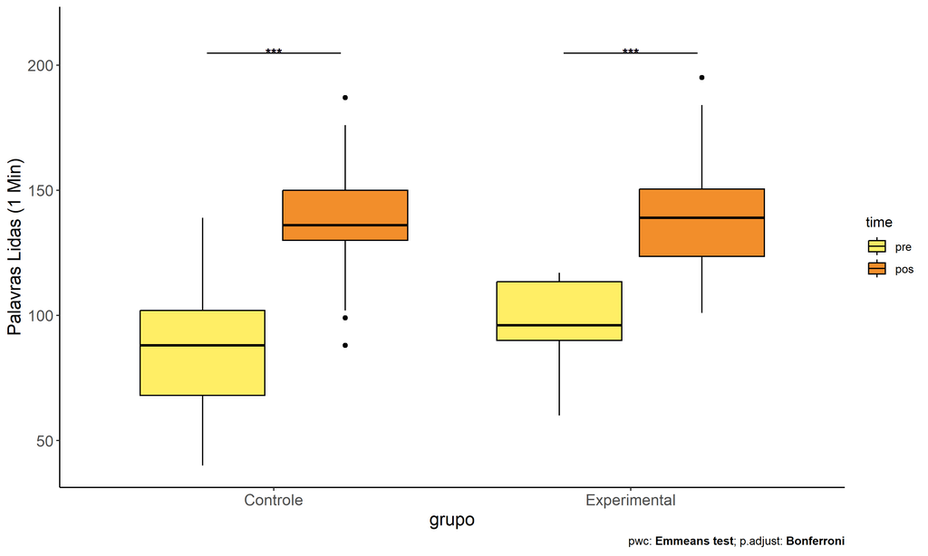

```r
if (length(unique(wdat.long[["grupo"]])) > 1)
  plots[["grupo"]] + ggplot2::ylab("Palavras Lidas (1 Min)")
```

### Checking linearity assumption

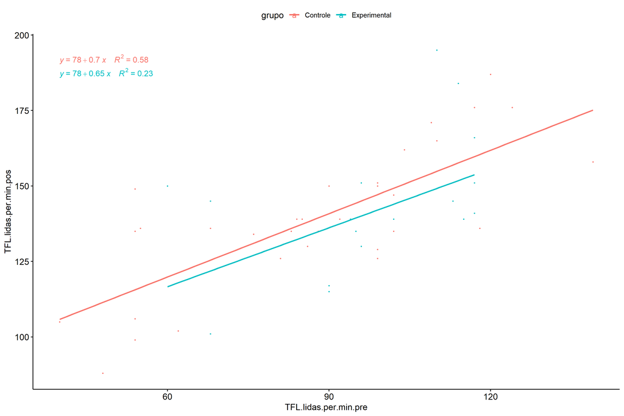

```r
ggscatter(wdat, x = "TFL.lidas.per.min.pre", y = "TFL.lidas.per.min.pos", size = 0.5,
          color = "grupo", add = "reg.line")+
  stat_regline_equation(
    aes(label =  paste(..eq.label.., ..rr.label.., sep = "~~~~"), color = grupo)
  )
```

### Checking normality and homogeneity

```r
res <- augment(lm(TFL.lidas.per.min.pos ~ TFL.lidas.per.min.pre + grupo, data = wdat))
```

```r
shapiro_test(res$.resid)
```

```
## # A tibble: 1 × 3
##   variable   statistic p.value
##   <chr>          <dbl>   <dbl>
## 1 res$.resid     0.950  0.0305
```

```r
levene_test(res, .resid ~ grupo)
```

```
## # A tibble: 1 × 4
##     df1   df2 statistic     p
##   <int> <int>     <dbl> <dbl>
## 1     1    50      1.37 0.248
```

# ANCOVA and Pairwise for two factors **grupo:Sexo**

## Without remove non-normal data

```r
pdat = remove_group_data(dat[!is.na(dat[["grupo"]]) & !is.na(dat[["Sexo"]]),], "TFL.lidas.per.min.pos", c("grupo","Sexo"))

pdat.long <- rbind(pdat[,c("id","grupo","Sexo")], pdat[,c("id","grupo","Sexo")])
pdat.long[["time"]] <- c(rep("pre", nrow(pdat)), rep("pos", nrow(pdat)))
pdat.long[["time"]] <- factor(pdat.long[["time"]], c("pre","pos"))
pdat.long[["TFL.lidas.per.min"]] <- c(pdat[["TFL.lidas.per.min.pre"]], pdat[["TFL.lidas.per.min.pos"]])

aov = anova_test(pdat, TFL.lidas.per.min.pos ~ TFL.lidas.per.min.pre + grupo*Sexo)
laov[["grupo:Sexo"]] <- get_anova_table(aov)
```

```r
pwcs <- list()
pwcs[["Sexo"]] <- emmeans_test(
  group_by(pdat, grupo), TFL.lidas.per.min.pos ~ Sexo,
  covariate = TFL.lidas.per.min.pre, p.adjust.method = "bonferroni")
pwcs[["grupo"]] <- emmeans_test(
  group_by(pdat, Sexo), TFL.lidas.per.min.pos ~ grupo,
  covariate = TFL.lidas.per.min.pre, p.adjust.method = "bonferroni")

pwc <- plyr::rbind.fill(pwcs[["grupo"]], pwcs[["Sexo"]])
pwc <- pwc[,c("grupo","Sexo", colnames(pwc)[!colnames(pwc) %in% c("grupo","Sexo")])]
```

```r
pwc.long <- emmeans_test(dplyr::group_by_at(pdat.long, c("grupo","Sexo")),
                         TFL.lidas.per.min ~ time,
                         p.adjust.method = "bonferroni")
lpwc[["grupo:Sexo"]] <- plyr::rbind.fill(pwc, pwc.long)
```

```r
ds <- get.descriptives(pdat, "TFL.lidas.per.min.pos", c("grupo","Sexo"), covar = "TFL.lidas.per.min.pre")
ds <- merge(ds[ds$variable != "TFL.lidas.per.min.pre",],
            ds[ds$variable == "TFL.lidas.per.min.pre", !colnames(ds) %in% c("variable")],
            by = c("grupo","Sexo"), all.x = T, suffixes = c("", ".TFL.lidas.per.min.pre"))
ds <- merge(get_emmeans(pwcs[["grupo"]]), ds, by = c("grupo","Sexo"), suffixes = c(".emms", ""))
ds <- ds[,c("grupo","Sexo","n","mean.TFL.lidas.per.min.pre","se.TFL.lidas.per.min.pre","mean","se","emmean","se.emms")]

colnames(ds) <- c("grupo","Sexo", "N", paste0(c("M","SE")," (pre)"),
                  paste0(c("M","SE"), " (unadj)"), paste0(c("M", "SE"), " (adj)"))

lemms[["grupo:Sexo"]] <- ds
```

## Computing ANCOVA and PairWise After removing non-normal data (OK)

```r
wdat = pdat

res = residuals(lm(TFL.lidas.per.min.pos ~ TFL.lidas.per.min.pre + grupo*Sexo, data = wdat))
non.normal = getNonNormal(res, wdat$id, plimit = 0.05)

wdat = wdat[!wdat$id %in% non.normal,]

wdat.long <- rbind(wdat[,c("id","grupo","Sexo")], wdat[,c("id","grupo","Sexo")])
wdat.long[["time"]] <- c(rep("pre", nrow(wdat)), rep("pos", nrow(wdat)))
wdat.long[["time"]] <- factor(wdat.long[["time"]], c("pre","pos"))
wdat.long[["TFL.lidas.per.min"]] <- c(wdat[["TFL.lidas.per.min.pre"]], wdat[["TFL.lidas.per.min.pos"]])


ldat[["grupo:Sexo"]] = wdat

(non.normal)
```

```
##  [1] "P1768" "P121"  "P2250" "P2380" "P1743" "P2220" "P2378" "P510"  "P2385" "P2404" "P2214" "P2377" "P2294"
## [14] "P1698" "P945"  "P2209"
```

```r
aov = anova_test(wdat, TFL.lidas.per.min.pos ~ TFL.lidas.per.min.pre + grupo*Sexo)
laov[["grupo:Sexo"]] <- merge(get_anova_table(aov), laov[["grupo:Sexo"]], by="Effect", suffixes = c("","'"))

(df = get_anova_table(aov))
```

```
## ANOVA Table (type II tests)
##
##                  Effect DFn DFd      F        p p<.05   ges
## 1 TFL.lidas.per.min.pre   1 123 81.449 3.01e-15     * 0.398
## 2                 grupo   1 123  0.506 4.78e-01       0.004
## 3                  Sexo   1 123 11.520 9.27e-04     * 0.086
## 4            grupo:Sexo   1 123  0.986 3.23e-01       0.008
```

| Effect | DFn | DFd | F | p | p<.05 | ges |
| --- | --- | --- | --- | --- | --- | --- |
| TFL.lidas.per.min.pre | 1 | 123 | 81.449 | 0.000 | * | 0.398 |
| grupo | 1 | 123 | 0.506 | 0.478 |  | 0.004 |
| Sexo | 1 | 123 | 11.520 | 0.001 | * | 0.086 |
| grupo:Sexo | 1 | 123 | 0.986 | 0.323 |  | 0.008 |

```r
pwcs <- list()
pwcs[["Sexo"]] <- emmeans_test(
  group_by(wdat, grupo), TFL.lidas.per.min.pos ~ Sexo,
  covariate = TFL.lidas.per.min.pre, p.adjust.method = "bonferroni")
pwcs[["grupo"]] <- emmeans_test(
  group_by(wdat, Sexo), TFL.lidas.per.min.pos ~ grupo,
  covariate = TFL.lidas.per.min.pre, p.adjust.method = "bonferroni")

pwc <- plyr::rbind.fill(pwcs[["grupo"]], pwcs[["Sexo"]])
pwc <- pwc[,c("grupo","Sexo", colnames(pwc)[!colnames(pwc) %in% c("grupo","Sexo")])]
```

| grupo | Sexo | term | .y. | group1 | group2 | df | statistic | p | p.adj | p.adj.signif |
| --- | --- | --- | --- | --- | --- | --- | --- | --- | --- | --- |
|  | F | TFL.lidas.per.min.pre*grupo | TFL.lidas.per.min.pos | Controle | Experimental | 123 | 0.332 | 0.741 | 0.741 | ns |
|  | M | TFL.lidas.per.min.pre*grupo | TFL.lidas.per.min.pos | Controle | Experimental | 123 | -1.177 | 0.241 | 0.241 | ns |
| Controle |  | TFL.lidas.per.min.pre*Sexo | TFL.lidas.per.min.pos | F | M | 123 | 3.299 | 0.001 | 0.001 | ** |
| Experimental |  | TFL.lidas.per.min.pre*Sexo | TFL.lidas.per.min.pos | F | M | 123 | 1.293 | 0.198 | 0.198 | ns |

```r
pwc.long <- emmeans_test(dplyr::group_by_at(wdat.long, c("grupo","Sexo")),
                         TFL.lidas.per.min ~ time,
                         p.adjust.method = "bonferroni")
lpwc[["grupo:Sexo"]] <- merge(plyr::rbind.fill(pwc, pwc.long), lpwc[["grupo:Sexo"]], by=c("grupo","Sexo","term",".y.","group1","group2"), suffixes = c("","'"))
```

| grupo | Sexo | term | .y. | group1 | group2 | df | statistic | p | p.adj | p.adj.signif |
| --- | --- | --- | --- | --- | --- | --- | --- | --- | --- | --- |
| Controle | F | time | TFL.lidas.per.min | pre | pos | 248 | -4.063 | 0.000 | 0.000 | **** |
| Controle | M | time | TFL.lidas.per.min | pre | pos | 248 | -2.189 | 0.030 | 0.030 | * |
| Experimental | F | time | TFL.lidas.per.min | pre | pos | 248 | -2.483 | 0.014 | 0.014 | * |
| Experimental | M | time | TFL.lidas.per.min | pre | pos | 248 | -2.710 | 0.007 | 0.007 | ** |

```r
ds <- get.descriptives(wdat, "TFL.lidas.per.min.pos", c("grupo","Sexo"), covar = "TFL.lidas.per.min.pre")
ds <- merge(ds[ds$variable != "TFL.lidas.per.min.pre",],
            ds[ds$variable == "TFL.lidas.per.min.pre", !colnames(ds) %in% c("variable")],
            by = c("grupo","Sexo"), all.x = T, suffixes = c("", ".TFL.lidas.per.min.pre"))
ds <- merge(get_emmeans(pwcs[["grupo"]]), ds, by = c("grupo","Sexo"), suffixes = c(".emms", ""))
ds <- ds[,c("grupo","Sexo","n","mean.TFL.lidas.per.min.pre","se.TFL.lidas.per.min.pre","mean","se","emmean","se.emms")]

colnames(ds) <- c("grupo","Sexo", "N", paste0(c("M","SE")," (pre)"),
                  paste0(c("M","SE"), " (unadj)"), paste0(c("M", "SE"), " (adj)"))

lemms[["grupo:Sexo"]] <- merge(ds, lemms[["grupo:Sexo"]], by=c("grupo","Sexo"), suffixes = c("","'"))
```

| grupo | Sexo | N | M (pre) | SE (pre) | M (unadj) | SE (unadj) | M (adj) | SE (adj) |
| --- | --- | --- | --- | --- | --- | --- | --- | --- |
| Controle | F | 32 | 93.125 | 4.171 | 115.625 | 3.688 | 115.384 | 3.080 |
| Controle | M | 47 | 91.213 | 3.550 | 101.213 | 3.485 | 102.203 | 2.544 |
| Experimental | F | 19 | 101.474 | 3.288 | 119.316 | 4.743 | 113.698 | 4.045 |
| Experimental | M | 30 | 89.233 | 3.621 | 104.733 | 4.099 | 106.998 | 3.191 |

### Plots for ancova

```r
plots <- twoWayAncovaPlots(
  wdat, "TFL.lidas.per.min.pos", c("grupo","Sexo"), aov, pwcs, addParam = c("mean_se"),
  font.label.size=10, step.increase=0.05, p.label="p.adj",
  subtitle = which(aov$Effect == "grupo:Sexo"))
```

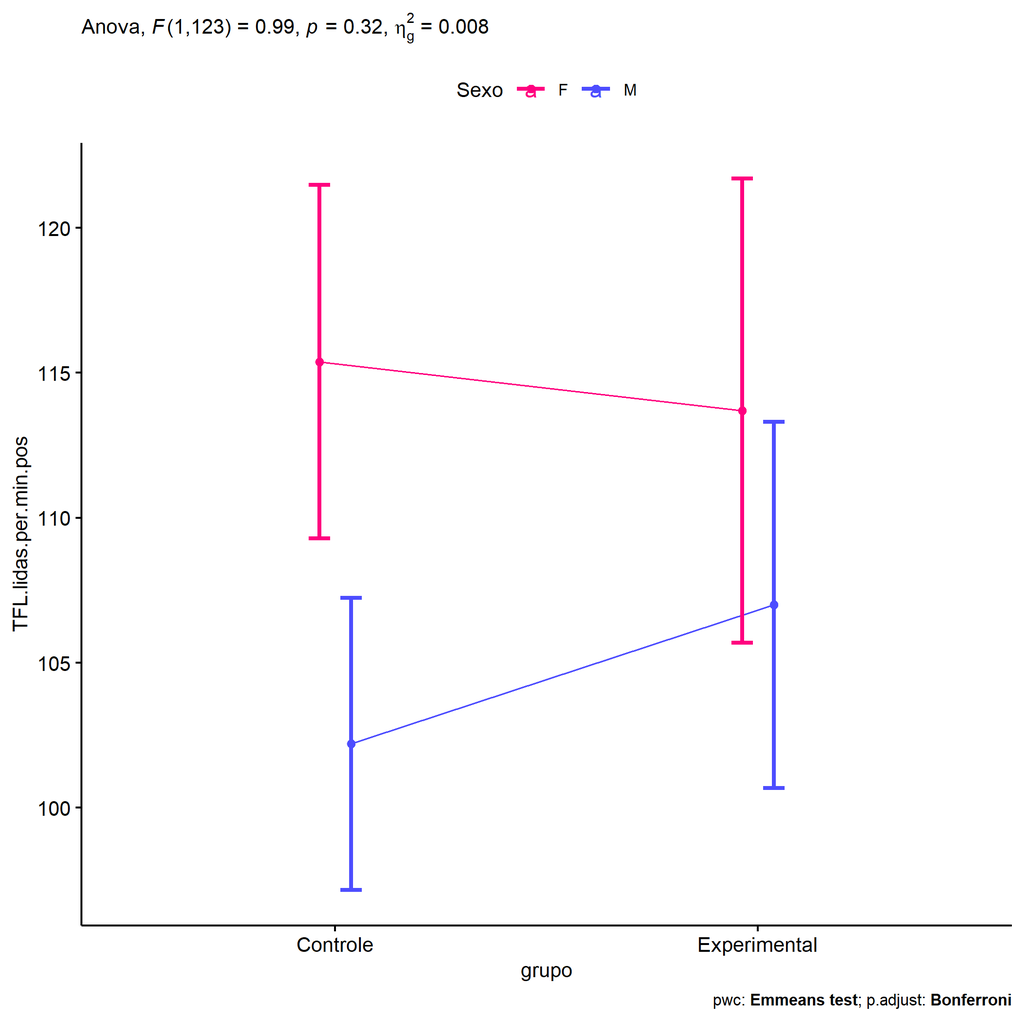

```r
if (!is.null(plots[["grupo"]]))
  plots[["grupo"]] + ggplot2::scale_color_manual(values = color[["Sexo"]])
```

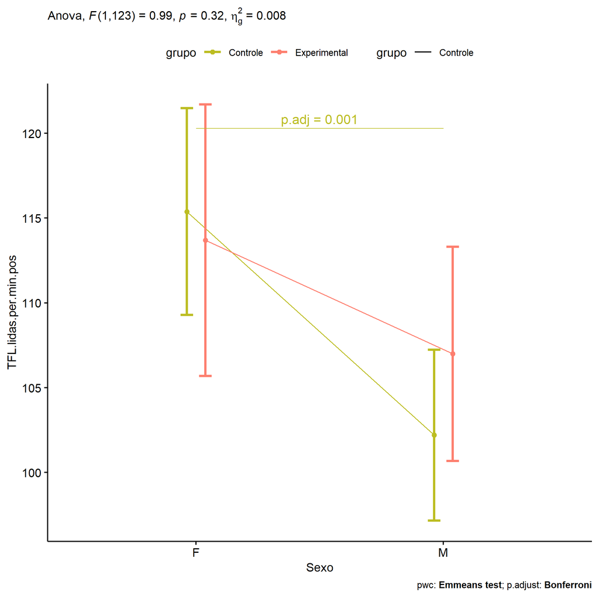

```r
if (!is.null(plots[["Sexo"]]))
  plots[["Sexo"]] + ggplot2::scale_color_manual(values = color[["grupo"]])
```

```r
plots <- twoWayAncovaBoxPlots(
  wdat, "TFL.lidas.per.min.pos", c("grupo","Sexo"), aov, pwcs, covar = "TFL.lidas.per.min.pre",
  theme = "classic", color = color[["grupo:Sexo"]],
  subtitle = which(aov$Effect == "grupo:Sexo"))
```

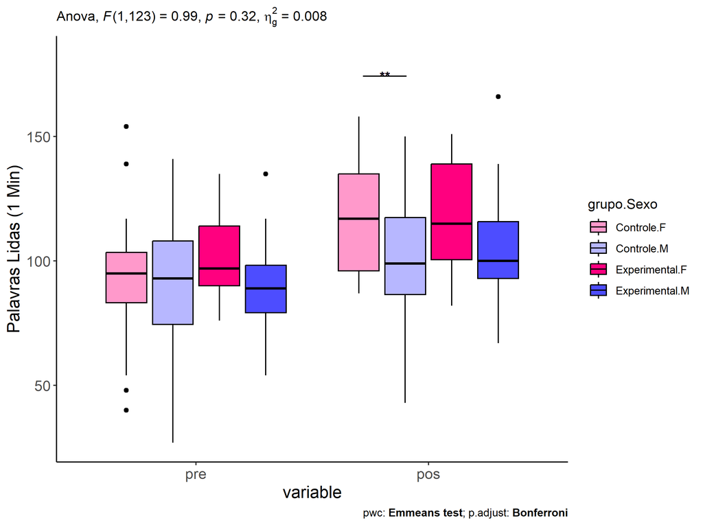

```r
plots[["grupo:Sexo"]] + ggplot2::ylab("Palavras Lidas (1 Min)") + ggplot2::scale_x_discrete(labels=c('pre', 'pos'))
```

```r
plots <- twoWayAncovaBoxPlots(
  wdat.long, "TFL.lidas.per.min", c("grupo","Sexo"), aov, pwc.long, pre.post = "time",
  theme = "classic", color = color$prepost)
```

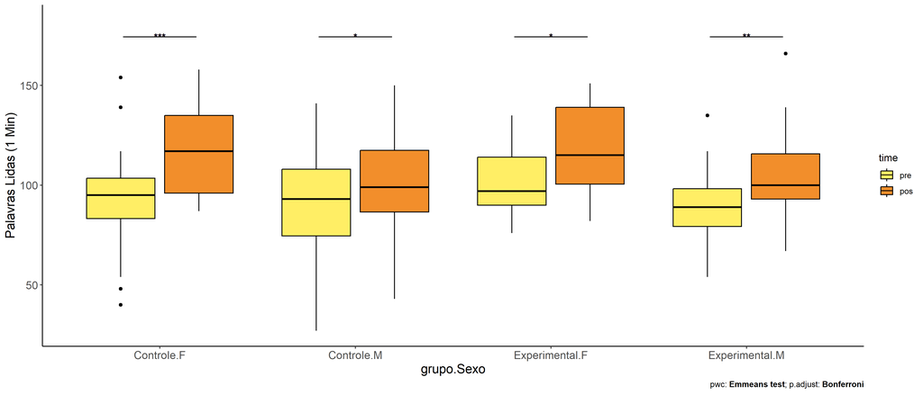

```r
plots[["grupo:Sexo"]] + ggplot2::ylab("Palavras Lidas (1 Min)")
```

### Checking linearity assumption

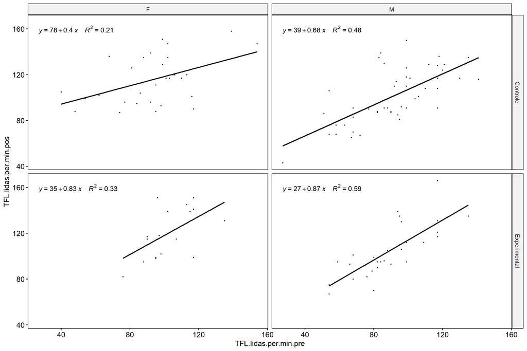

```r
ggscatter(wdat, x = "TFL.lidas.per.min.pre", y = "TFL.lidas.per.min.pos", size = 0.5,
          facet.by = c("grupo","Sexo"), add = "reg.line")+
  stat_regline_equation(
    aes(label =  paste(..eq.label.., ..rr.label.., sep = "~~~~"))
  )
```

### Checking normality and homogeneity

```r
res <- augment(lm(TFL.lidas.per.min.pos ~ TFL.lidas.per.min.pre + grupo*Sexo, data = wdat))
```

```r
shapiro_test(res$.resid)
```

```
## # A tibble: 1 × 3
##   variable   statistic p.value
##   <chr>          <dbl>   <dbl>
## 1 res$.resid     0.972  0.0102
```

```r
levene_test(res, .resid ~ grupo*Sexo)
```

```
## # A tibble: 1 × 4
##     df1   df2 statistic     p
##   <int> <int>     <dbl> <dbl>
## 1     3   124      1.04 0.376
```

# ANCOVA and Pairwise for two factors **grupo:Zona**

## Without remove non-normal data

```r
pdat = remove_group_data(dat[!is.na(dat[["grupo"]]) & !is.na(dat[["Zona"]]),], "TFL.lidas.per.min.pos", c("grupo","Zona"))

pdat.long <- rbind(pdat[,c("id","grupo","Zona")], pdat[,c("id","grupo","Zona")])
pdat.long[["time"]] <- c(rep("pre", nrow(pdat)), rep("pos", nrow(pdat)))
pdat.long[["time"]] <- factor(pdat.long[["time"]], c("pre","pos"))
pdat.long[["TFL.lidas.per.min"]] <- c(pdat[["TFL.lidas.per.min.pre"]], pdat[["TFL.lidas.per.min.pos"]])

aov = anova_test(pdat, TFL.lidas.per.min.pos ~ TFL.lidas.per.min.pre + grupo*Zona)
laov[["grupo:Zona"]] <- get_anova_table(aov)
```

```r
pwcs <- list()
pwcs[["Zona"]] <- emmeans_test(
  group_by(pdat, grupo), TFL.lidas.per.min.pos ~ Zona,
  covariate = TFL.lidas.per.min.pre, p.adjust.method = "bonferroni")
pwcs[["grupo"]] <- emmeans_test(
  group_by(pdat, Zona), TFL.lidas.per.min.pos ~ grupo,
  covariate = TFL.lidas.per.min.pre, p.adjust.method = "bonferroni")

pwc <- plyr::rbind.fill(pwcs[["grupo"]], pwcs[["Zona"]])
pwc <- pwc[,c("grupo","Zona", colnames(pwc)[!colnames(pwc) %in% c("grupo","Zona")])]
```

```r
pwc.long <- emmeans_test(dplyr::group_by_at(pdat.long, c("grupo","Zona")),
                         TFL.lidas.per.min ~ time,
                         p.adjust.method = "bonferroni")
lpwc[["grupo:Zona"]] <- plyr::rbind.fill(pwc, pwc.long)
```

```r
ds <- get.descriptives(pdat, "TFL.lidas.per.min.pos", c("grupo","Zona"), covar = "TFL.lidas.per.min.pre")
ds <- merge(ds[ds$variable != "TFL.lidas.per.min.pre",],
            ds[ds$variable == "TFL.lidas.per.min.pre", !colnames(ds) %in% c("variable")],
            by = c("grupo","Zona"), all.x = T, suffixes = c("", ".TFL.lidas.per.min.pre"))
ds <- merge(get_emmeans(pwcs[["grupo"]]), ds, by = c("grupo","Zona"), suffixes = c(".emms", ""))
ds <- ds[,c("grupo","Zona","n","mean.TFL.lidas.per.min.pre","se.TFL.lidas.per.min.pre","mean","se","emmean","se.emms")]

colnames(ds) <- c("grupo","Zona", "N", paste0(c("M","SE")," (pre)"),
                  paste0(c("M","SE"), " (unadj)"), paste0(c("M", "SE"), " (adj)"))

lemms[["grupo:Zona"]] <- ds
```

## Computing ANCOVA and PairWise After removing non-normal data (OK)

```r
wdat = pdat

res = residuals(lm(TFL.lidas.per.min.pos ~ TFL.lidas.per.min.pre + grupo*Zona, data = wdat))
non.normal = getNonNormal(res, wdat$id, plimit = 0.05)

wdat = wdat[!wdat$id %in% non.normal,]

wdat.long <- rbind(wdat[,c("id","grupo","Zona")], wdat[,c("id","grupo","Zona")])
wdat.long[["time"]] <- c(rep("pre", nrow(wdat)), rep("pos", nrow(wdat)))
wdat.long[["time"]] <- factor(wdat.long[["time"]], c("pre","pos"))
wdat.long[["TFL.lidas.per.min"]] <- c(wdat[["TFL.lidas.per.min.pre"]], wdat[["TFL.lidas.per.min.pos"]])


ldat[["grupo:Zona"]] = wdat

(non.normal)
```

```
## [1] "P1768" "P121"  "P2378" "P1743" "P2220" "P510"  "P1698"
```

```r
aov = anova_test(wdat, TFL.lidas.per.min.pos ~ TFL.lidas.per.min.pre + grupo*Zona)
laov[["grupo:Zona"]] <- merge(get_anova_table(aov), laov[["grupo:Zona"]], by="Effect", suffixes = c("","'"))

(df = get_anova_table(aov))
```

```
## ANOVA Table (type II tests)
##
##                  Effect DFn DFd      F        p p<.05   ges
## 1 TFL.lidas.per.min.pre   1  94 84.400 9.85e-15     * 0.473
## 2                 grupo   1  94  0.260 6.11e-01       0.003
## 3                  Zona   1  94 34.869 5.58e-08     * 0.271
## 4            grupo:Zona   1  94  8.262 5.00e-03     * 0.081
```

| Effect | DFn | DFd | F | p | p<.05 | ges |
| --- | --- | --- | --- | --- | --- | --- |
| TFL.lidas.per.min.pre | 1 | 94 | 84.400 | 0.000 | * | 0.473 |
| grupo | 1 | 94 | 0.260 | 0.611 |  | 0.003 |
| Zona | 1 | 94 | 34.869 | 0.000 | * | 0.271 |
| grupo:Zona | 1 | 94 | 8.262 | 0.005 | * | 0.081 |

```r
pwcs <- list()
pwcs[["Zona"]] <- emmeans_test(
  group_by(wdat, grupo), TFL.lidas.per.min.pos ~ Zona,
  covariate = TFL.lidas.per.min.pre, p.adjust.method = "bonferroni")
pwcs[["grupo"]] <- emmeans_test(
  group_by(wdat, Zona), TFL.lidas.per.min.pos ~ grupo,
  covariate = TFL.lidas.per.min.pre, p.adjust.method = "bonferroni")

pwc <- plyr::rbind.fill(pwcs[["grupo"]], pwcs[["Zona"]])
pwc <- pwc[,c("grupo","Zona", colnames(pwc)[!colnames(pwc) %in% c("grupo","Zona")])]
```

| grupo | Zona | term | .y. | group1 | group2 | df | statistic | p | p.adj | p.adj.signif |
| --- | --- | --- | --- | --- | --- | --- | --- | --- | --- | --- |
|  | Rural | TFL.lidas.per.min.pre*grupo | TFL.lidas.per.min.pos | Controle | Experimental | 94 | -0.545 | 0.587 | 0.587 | ns |
|  | Urbana | TFL.lidas.per.min.pre*grupo | TFL.lidas.per.min.pos | Controle | Experimental | 94 | 2.869 | 0.005 | 0.005 | ** |
| Controle |  | TFL.lidas.per.min.pre*Zona | TFL.lidas.per.min.pos | Rural | Urbana | 94 | -6.379 | 0.000 | 0.000 | **** |
| Experimental |  | TFL.lidas.per.min.pre*Zona | TFL.lidas.per.min.pos | Rural | Urbana | 94 | -1.565 | 0.121 | 0.121 | ns |

```r
pwc.long <- emmeans_test(dplyr::group_by_at(wdat.long, c("grupo","Zona")),
                         TFL.lidas.per.min ~ time,
                         p.adjust.method = "bonferroni")
lpwc[["grupo:Zona"]] <- merge(plyr::rbind.fill(pwc, pwc.long), lpwc[["grupo:Zona"]], by=c("grupo","Zona","term",".y.","group1","group2"), suffixes = c("","'"))
```

| grupo | Zona | term | .y. | group1 | group2 | df | statistic | p | p.adj | p.adj.signif |
| --- | --- | --- | --- | --- | --- | --- | --- | --- | --- | --- |
| Controle | Rural | time | TFL.lidas.per.min | pre | pos | 190 | -2.549 | 0.012 | 0.012 | * |
| Controle | Urbana | time | TFL.lidas.per.min | pre | pos | 190 | -4.227 | 0.000 | 0.000 | **** |
| Experimental | Rural | time | TFL.lidas.per.min | pre | pos | 190 | -2.356 | 0.019 | 0.019 | * |
| Experimental | Urbana | time | TFL.lidas.per.min | pre | pos | 190 | -1.505 | 0.134 | 0.134 | ns |

```r
ds <- get.descriptives(wdat, "TFL.lidas.per.min.pos", c("grupo","Zona"), covar = "TFL.lidas.per.min.pre")
ds <- merge(ds[ds$variable != "TFL.lidas.per.min.pre",],
            ds[ds$variable == "TFL.lidas.per.min.pre", !colnames(ds) %in% c("variable")],
            by = c("grupo","Zona"), all.x = T, suffixes = c("", ".TFL.lidas.per.min.pre"))
ds <- merge(get_emmeans(pwcs[["grupo"]]), ds, by = c("grupo","Zona"), suffixes = c(".emms", ""))
ds <- ds[,c("grupo","Zona","n","mean.TFL.lidas.per.min.pre","se.TFL.lidas.per.min.pre","mean","se","emmean","se.emms")]

colnames(ds) <- c("grupo","Zona", "N", paste0(c("M","SE")," (pre)"),
                  paste0(c("M","SE"), " (unadj)"), paste0(c("M", "SE"), " (adj)"))

lemms[["grupo:Zona"]] <- merge(ds, lemms[["grupo:Zona"]], by=c("grupo","Zona"), suffixes = c("","'"))
```

| grupo | Zona | N | M (pre) | SE (pre) | M (unadj) | SE (unadj) | M (adj) | SE (adj) |
| --- | --- | --- | --- | --- | --- | --- | --- | --- |
| Controle | Rural | 55 | 92.764 | 3.462 | 103.491 | 2.981 | 103.544 | 2.066 |
| Controle | Urbana | 7 | 93.000 | 9.092 | 142.857 | 10.734 | 142.762 | 5.791 |
| Experimental | Rural | 32 | 91.656 | 3.195 | 104.656 | 3.030 | 105.402 | 2.710 |
| Experimental | Urbana | 5 | 101.200 | 8.540 | 122.200 | 8.800 | 116.977 | 6.875 |

### Plots for ancova

```r
plots <- twoWayAncovaPlots(
  wdat, "TFL.lidas.per.min.pos", c("grupo","Zona"), aov, pwcs, addParam = c("mean_se"),
  font.label.size=10, step.increase=0.05, p.label="p.adj",
  subtitle = which(aov$Effect == "grupo:Zona"))
```

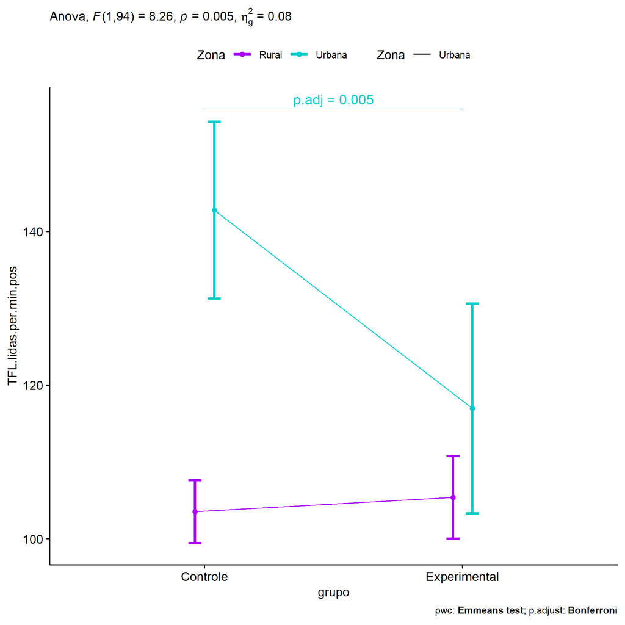

```r
if (!is.null(plots[["grupo"]]))
  plots[["grupo"]] + ggplot2::scale_color_manual(values = color[["Zona"]])
```

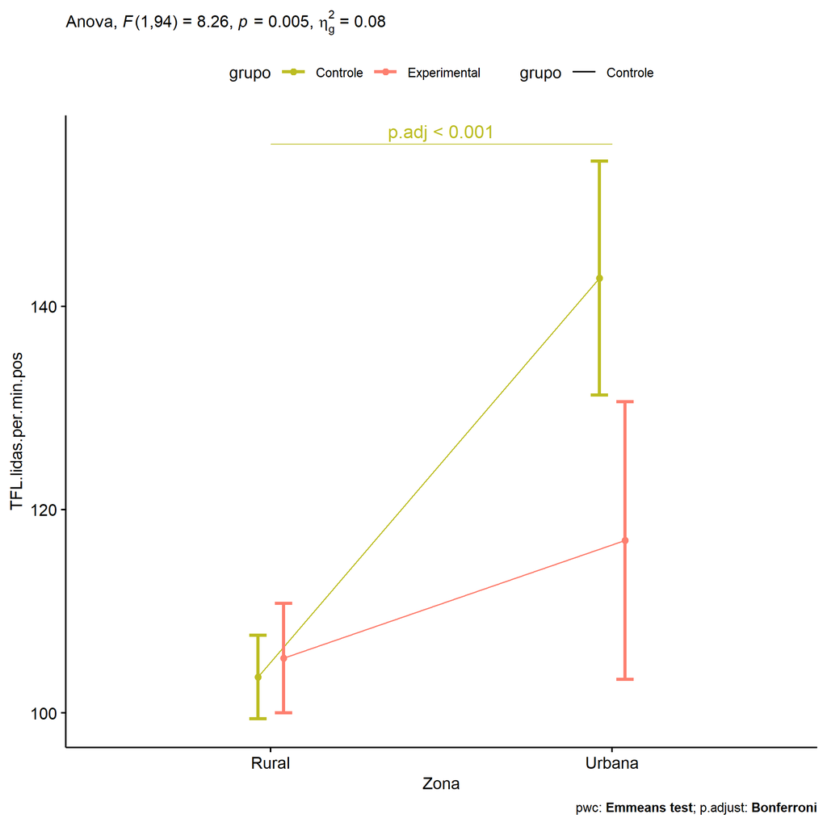

```r
if (!is.null(plots[["Zona"]]))
  plots[["Zona"]] + ggplot2::scale_color_manual(values = color[["grupo"]])
```

```r
plots <- twoWayAncovaBoxPlots(
  wdat, "TFL.lidas.per.min.pos", c("grupo","Zona"), aov, pwcs, covar = "TFL.lidas.per.min.pre",
  theme = "classic", color = color[["grupo:Zona"]],
  subtitle = which(aov$Effect == "grupo:Zona"))
```

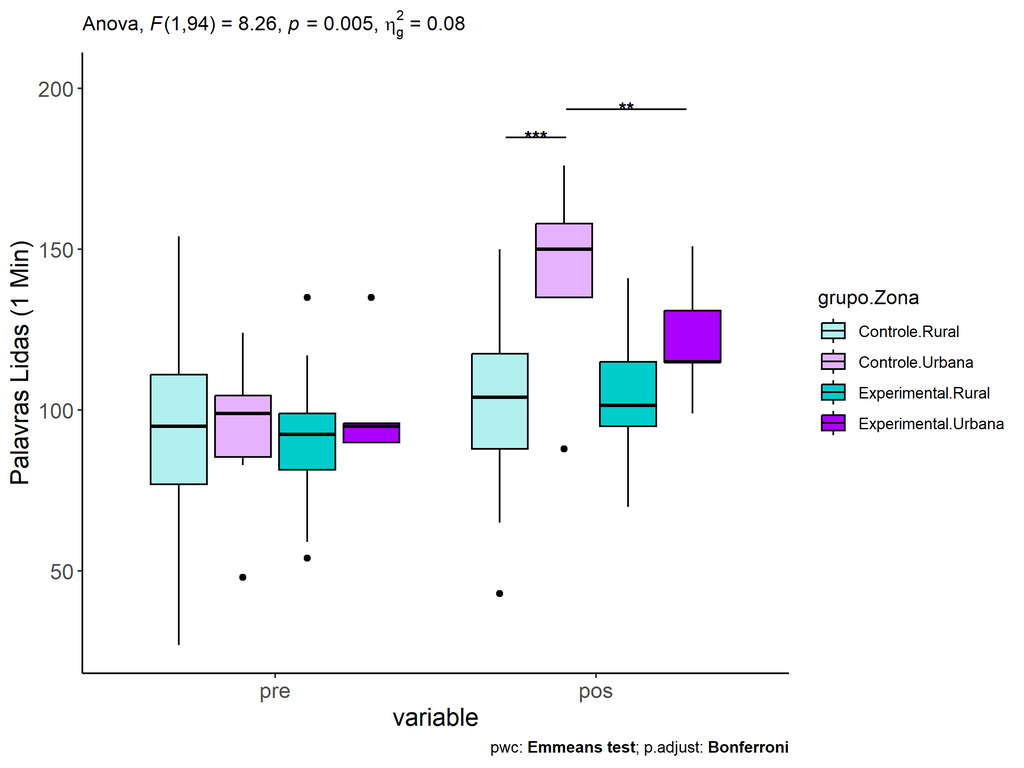

```r
plots[["grupo:Zona"]] + ggplot2::ylab("Palavras Lidas (1 Min)") + ggplot2::scale_x_discrete(labels=c('pre', 'pos'))
```

```r
plots <- twoWayAncovaBoxPlots(
  wdat.long, "TFL.lidas.per.min", c("grupo","Zona"), aov, pwc.long, pre.post = "time",
  theme = "classic", color = color$prepost)
```

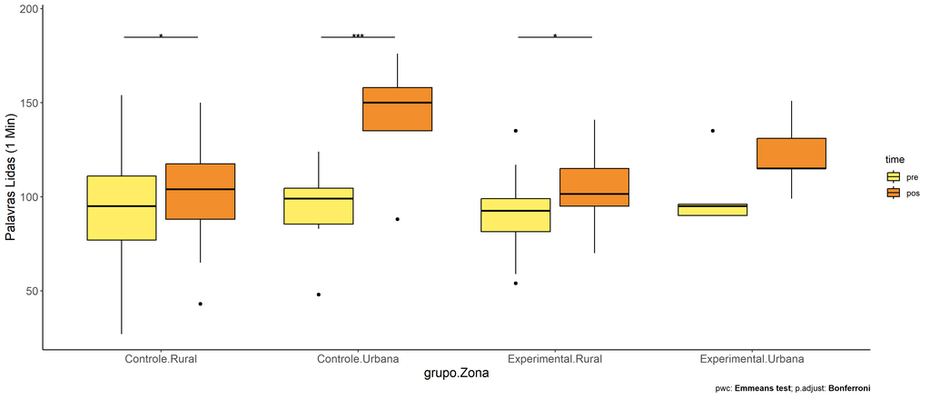

```r
plots[["grupo:Zona"]] + ggplot2::ylab("Palavras Lidas (1 Min)")
```

### Checking linearity assumption

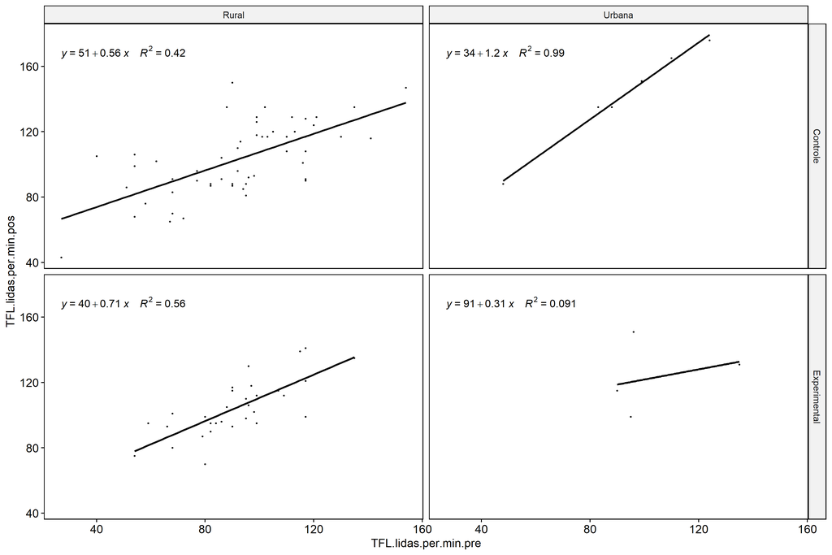

```r
ggscatter(wdat, x = "TFL.lidas.per.min.pre", y = "TFL.lidas.per.min.pos", size = 0.5,
          facet.by = c("grupo","Zona"), add = "reg.line")+
  stat_regline_equation(
    aes(label =  paste(..eq.label.., ..rr.label.., sep = "~~~~"))
  )
```

### Checking normality and homogeneity

```r
res <- augment(lm(TFL.lidas.per.min.pos ~ TFL.lidas.per.min.pre + grupo*Zona, data = wdat))
```

```r
shapiro_test(res$.resid)
```

```
## # A tibble: 1 × 3
##   variable   statistic p.value
##   <chr>          <dbl>   <dbl>
## 1 res$.resid     0.982   0.212
```

```r
levene_test(res, .resid ~ grupo*Zona)
```

```
## # A tibble: 1 × 4
##     df1   df2 statistic     p
##   <int> <int>     <dbl> <dbl>
## 1     3    95      2.06 0.111
```

# ANCOVA and Pairwise for two factors **grupo:Cor.Raca**

## Without remove non-normal data

```r
pdat = remove_group_data(dat[!is.na(dat[["grupo"]]) & !is.na(dat[["Cor.Raca"]]),], "TFL.lidas.per.min.pos", c("grupo","Cor.Raca"))
pdat.long <- rbind(pdat[,c("id","grupo","Cor.Raca")], pdat[,c("id","grupo","Cor.Raca")])
pdat.long[["time"]] <- c(rep("pre", nrow(pdat)), rep("pos", nrow(pdat)))
pdat.long[["time"]] <- factor(pdat.long[["time"]], c("pre","pos"))
pdat.long[["TFL.lidas.per.min"]] <- c(pdat[["TFL.lidas.per.min.pre"]], pdat[["TFL.lidas.per.min.pos"]])

aov = anova_test(pdat, TFL.lidas.per.min.pos ~ TFL.lidas.per.min.pre + grupo*Cor.Raca)
laov[["grupo:Cor.Raca"]] <- get_anova_table(aov)
```

```r
pwcs <- list()
pwcs[["Cor.Raca"]] <- emmeans_test(
  group_by(pdat, grupo), TFL.lidas.per.min.pos ~ Cor.Raca,
  covariate = TFL.lidas.per.min.pre, p.adjust.method = "bonferroni")
pwcs[["grupo"]] <- emmeans_test(
  group_by(pdat, Cor.Raca), TFL.lidas.per.min.pos ~ grupo,
  covariate = TFL.lidas.per.min.pre, p.adjust.method = "bonferroni")

pwc <- plyr::rbind.fill(pwcs[["grupo"]], pwcs[["Cor.Raca"]])
pwc <- pwc[,c("grupo","Cor.Raca", colnames(pwc)[!colnames(pwc) %in% c("grupo","Cor.Raca")])]
```

```r
pwc.long <- emmeans_test(dplyr::group_by_at(pdat.long, c("grupo","Cor.Raca")),
                         TFL.lidas.per.min ~ time,
                         p.adjust.method = "bonferroni")
lpwc[["grupo:Cor.Raca"]] <- plyr::rbind.fill(pwc, pwc.long)
```

```r
ds <- get.descriptives(pdat, "TFL.lidas.per.min.pos", c("grupo","Cor.Raca"), covar = "TFL.lidas.per.min.pre")
ds <- merge(ds[ds$variable != "TFL.lidas.per.min.pre",],
            ds[ds$variable == "TFL.lidas.per.min.pre", !colnames(ds) %in% c("variable")],
            by = c("grupo","Cor.Raca"), all.x = T, suffixes = c("", ".TFL.lidas.per.min.pre"))
ds <- merge(get_emmeans(pwcs[["grupo"]]), ds, by = c("grupo","Cor.Raca"), suffixes = c(".emms", ""))
ds <- ds[,c("grupo","Cor.Raca","n","mean.TFL.lidas.per.min.pre","se.TFL.lidas.per.min.pre","mean","se","emmean","se.emms")]

colnames(ds) <- c("grupo","Cor.Raca", "N", paste0(c("M","SE")," (pre)"),
                  paste0(c("M","SE"), " (unadj)"), paste0(c("M", "SE"), " (adj)"))

lemms[["grupo:Cor.Raca"]] <- ds
```

## Computing ANCOVA and PairWise After removing non-normal data (OK)

```r
wdat = pdat

res = residuals(lm(TFL.lidas.per.min.pos ~ TFL.lidas.per.min.pre + grupo*Cor.Raca, data = wdat))
non.normal = getNonNormal(res, wdat$id, plimit = 0.05)

wdat = wdat[!wdat$id %in% non.normal,]

wdat.long <- rbind(wdat[,c("id","grupo","Cor.Raca")], wdat[,c("id","grupo","Cor.Raca")])
wdat.long[["time"]] <- c(rep("pre", nrow(wdat)), rep("pos", nrow(wdat)))
wdat.long[["time"]] <- factor(wdat.long[["time"]], c("pre","pos"))
wdat.long[["TFL.lidas.per.min"]] <- c(wdat[["TFL.lidas.per.min.pre"]], wdat[["TFL.lidas.per.min.pos"]])


ldat[["grupo:Cor.Raca"]] = wdat

(non.normal)
```

```
## [1] "P510"  "P1728"
```

```r
aov = anova_test(wdat, TFL.lidas.per.min.pos ~ TFL.lidas.per.min.pre + grupo*Cor.Raca)
laov[["grupo:Cor.Raca"]] <- merge(get_anova_table(aov), laov[["grupo:Cor.Raca"]], by="Effect", suffixes = c("","'"))

(df = get_anova_table(aov))
```

```
## ANOVA Table (type II tests)
##
##                  Effect DFn DFd      F        p p<.05   ges
## 1 TFL.lidas.per.min.pre   1  75 62.801 1.66e-11     * 0.456
## 2                 grupo   1  75  2.933 9.10e-02       0.038
## 3              Cor.Raca   2  75  3.311 4.20e-02     * 0.081
## 4        grupo:Cor.Raca   1  75  0.648 4.23e-01       0.009
```

| Effect | DFn | DFd | F | p | p<.05 | ges |
| --- | --- | --- | --- | --- | --- | --- |
| TFL.lidas.per.min.pre | 1 | 75 | 62.801 | 0.000 | * | 0.456 |
| grupo | 1 | 75 | 2.933 | 0.091 |  | 0.038 |
| Cor.Raca | 2 | 75 | 3.311 | 0.042 | * | 0.081 |
| grupo:Cor.Raca | 1 | 75 | 0.648 | 0.423 |  | 0.009 |

```r
pwcs <- list()
pwcs[["Cor.Raca"]] <- emmeans_test(
  group_by(wdat, grupo), TFL.lidas.per.min.pos ~ Cor.Raca,
  covariate = TFL.lidas.per.min.pre, p.adjust.method = "bonferroni")
pwcs[["grupo"]] <- emmeans_test(
  group_by(wdat, Cor.Raca), TFL.lidas.per.min.pos ~ grupo,
  covariate = TFL.lidas.per.min.pre, p.adjust.method = "bonferroni")

pwc <- plyr::rbind.fill(pwcs[["grupo"]], pwcs[["Cor.Raca"]])
pwc <- pwc[,c("grupo","Cor.Raca", colnames(pwc)[!colnames(pwc) %in% c("grupo","Cor.Raca")])]
```

| grupo | Cor.Raca | term | .y. | group1 | group2 | df | statistic | p | p.adj | p.adj.signif |
| --- | --- | --- | --- | --- | --- | --- | --- | --- | --- | --- |
|  | Branca | TFL.lidas.per.min.pre*grupo | TFL.lidas.per.min.pos | Controle | Experimental | 75 | -1.537 | 0.129 | 0.129 | ns |
|  | Indígena | TFL.lidas.per.min.pre*grupo | TFL.lidas.per.min.pos | Controle | Experimental |  |  |  |  |  |
|  | Parda | TFL.lidas.per.min.pre*grupo | TFL.lidas.per.min.pos | Controle | Experimental | 75 | -1.106 | 0.272 | 0.272 | ns |
| Controle |  | TFL.lidas.per.min.pre*Cor.Raca | TFL.lidas.per.min.pos | Branca | Indígena |  |  |  |  |  |
| Controle |  | TFL.lidas.per.min.pre*Cor.Raca | TFL.lidas.per.min.pos | Branca | Parda | 75 | 1.753 | 0.084 | 0.084 | ns |
| Controle |  | TFL.lidas.per.min.pre*Cor.Raca | TFL.lidas.per.min.pos | Indígena | Parda |  |  |  |  |  |
| Experimental |  | TFL.lidas.per.min.pre*Cor.Raca | TFL.lidas.per.min.pos | Branca | Indígena | 75 | 1.655 | 0.102 | 0.306 | ns |
| Experimental |  | TFL.lidas.per.min.pre*Cor.Raca | TFL.lidas.per.min.pos | Branca | Parda | 75 | 2.086 | 0.040 | 0.121 | ns |
| Experimental |  | TFL.lidas.per.min.pre*Cor.Raca | TFL.lidas.per.min.pos | Indígena | Parda | 75 | 0.312 | 0.756 | 1.000 | ns |

```r
pwc.long <- emmeans_test(dplyr::group_by_at(wdat.long, c("grupo","Cor.Raca")),
                         TFL.lidas.per.min ~ time,
                         p.adjust.method = "bonferroni")
lpwc[["grupo:Cor.Raca"]] <- merge(plyr::rbind.fill(pwc, pwc.long), lpwc[["grupo:Cor.Raca"]], by=c("grupo","Cor.Raca","term",".y.","group1","group2"), suffixes = c("","'"))
```

| grupo | Cor.Raca | term | .y. | group1 | group2 | df | statistic | p | p.adj | p.adj.signif |
| --- | --- | --- | --- | --- | --- | --- | --- | --- | --- | --- |
| Controle | Branca | time | TFL.lidas.per.min | pre | pos | 152 | -1.181 | 0.239 | 0.239 | ns |
| Controle | Indígena | time | TFL.lidas.per.min | pre | pos |  |  |  |  |  |
| Controle | Parda | time | TFL.lidas.per.min | pre | pos | 152 | -1.343 | 0.181 | 0.181 | ns |
| Experimental | Branca | time | TFL.lidas.per.min | pre | pos | 152 | -1.738 | 0.084 | 0.084 | ns |
| Experimental | Indígena | time | TFL.lidas.per.min | pre | pos | 152 | -1.143 | 0.255 | 0.255 | ns |
| Experimental | Parda | time | TFL.lidas.per.min | pre | pos | 152 | -1.659 | 0.099 | 0.099 | ns |

```r
ds <- get.descriptives(wdat, "TFL.lidas.per.min.pos", c("grupo","Cor.Raca"), covar = "TFL.lidas.per.min.pre")
ds <- merge(ds[ds$variable != "TFL.lidas.per.min.pre",],
            ds[ds$variable == "TFL.lidas.per.min.pre", !colnames(ds) %in% c("variable")],
            by = c("grupo","Cor.Raca"), all.x = T, suffixes = c("", ".TFL.lidas.per.min.pre"))
ds <- merge(get_emmeans(pwcs[["grupo"]]), ds, by = c("grupo","Cor.Raca"), suffixes = c(".emms", ""))
ds <- ds[,c("grupo","Cor.Raca","n","mean.TFL.lidas.per.min.pre","se.TFL.lidas.per.min.pre","mean","se","emmean","se.emms")]

colnames(ds) <- c("grupo","Cor.Raca", "N", paste0(c("M","SE")," (pre)"),
                  paste0(c("M","SE"), " (unadj)"), paste0(c("M", "SE"), " (adj)"))

lemms[["grupo:Cor.Raca"]] <- merge(ds, lemms[["grupo:Cor.Raca"]], by=c("grupo","Cor.Raca"), suffixes = c("","'"))
```

| grupo | Cor.Raca | N | M (pre) | SE (pre) | M (unadj) | SE (unadj) | M (adj) | SE (adj) |
| --- | --- | --- | --- | --- | --- | --- | --- | --- |
| Controle | Branca | 12 | 105.500 | 4.588 | 115.417 | 5.237 | 108.172 | 4.381 |
| Controle | Parda | 40 | 91.525 | 3.737 | 97.700 | 3.276 | 99.384 | 2.356 |
| Experimental | Branca | 5 | 104.000 | 5.310 | 126.600 | 8.322 | 120.314 | 6.685 |
| Experimental | Indígena | 8 | 95.125 | 6.839 | 106.875 | 7.527 | 106.259 | 5.248 |
| Experimental | Parda | 16 | 88.688 | 5.065 | 100.750 | 4.760 | 104.246 | 3.737 |